# Script3_Armbruster2026_NormalizationClusteringAnnotation

## 6.14 Annotate clusters

- Cluster identities were assigned based on marker gene expression analysis above.

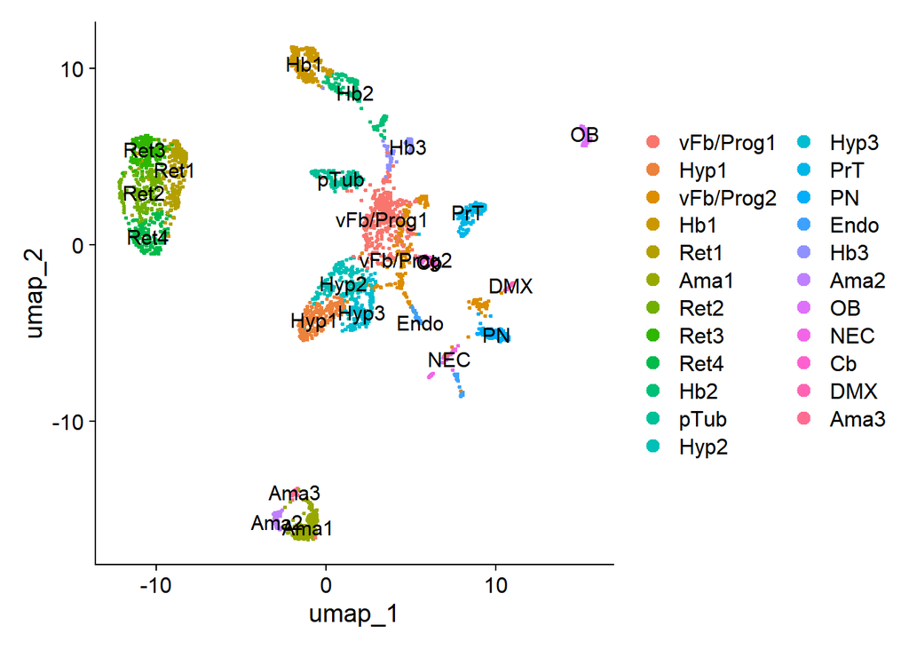

```r
Idents(object = normalized_cells) <- "SCT_snn_res.1"

normalized_cells <- RenameIdents(normalized_cells,
                                 "0" = "vFb/Prog1",
                                 "1" = "Hyp1",
                                 "2" = "vFb/Prog2",
                                 "3" = "Hb1",
                                 "4" = "Ret1",
                                 "5" = "Ama1",
                                 "6" = "Ret2",
                                 "7" = "Ret3",
                                 "8" = "Ret4",
                                 "9" = "Hb2",
                                 "10" = "pTub",
                                 "11" = "Hyp2",
                                 "12" = "Hyp3",
                                 "13" = "PrT",
                                 "14" = "PN",
                                 "15" = "Endo",
                                 "16" = "Hb3",
                                 "17" = "Ama2",
                                 "18" = "OB",
                                 "19" = "NEC",
                                 "20" = "Cb",
                                 "21" = "DMX",
                                 "22" = "Ama3"
                                 )


normalized_cells$Fig1_annotation <- normalized_cells@active.ident

DimPlot(normalized_cells, label = T)
```

# 7. DEG Analysis of annotated object

- To identify cluster-specific genes DEG analysis was performed on the annotated Seurat object. Only positively enriched genes expressed in at least 20% of cells with a log2FC of at least 0.25 and a adjusted p-value < 0.05 were considered as cluster specific.

```r
# Calculate DEGs and generate dataframes for all DEGs and TF DEGs (SCT assay, data slot)
norm_markers <- FindAllMarkers(normalized_cells, only.pos = TRUE, min.pct = 0.2, logfc.threshold = .25)
```

[output not shown]

```r
# Only include DEGs with adjusted p-value < 0.05
try(norm_markers <- dplyr::filter(norm_markers, p_val_adj <= 0.05))

# Sort by avg_log2FC
norm_markers_sorted <- norm_markers %>% group_by(cluster) %>% dplyr::arrange(desc(avg_log2FC), .by_group = T)


# Gene as first column
norm_markers_sorted <- norm_markers_sorted %>% relocate(gene, .before = p_val) %>% relocate(cluster, .before = gene)

# Load zebrafish transcription factor annotation list used to extract transcription factors from DEG results ( List from Animal Transcription Factor Database 3.0 (AnimalTFDB3.9))
TFlist <- read_tsv(file = "Resources/DanioRerio_TF.tsv")
```

```r
# Rename gene symbol column and remove unnecessary annotation columns
names(TFlist)[names(TFlist) == "Symbol"] <- "gene"
TFlist$Species <- NULL
TFlist$Ensembl <- NULL
TFlist$Family <- NULL
TFlist$Protein <- NULL
TFlist$`Entrez ID` <- NULL

# Remove duplicated transcription factor entries
TFlist <- TFlist[!duplicated(TFlist), ]

# Extract transcription factor genes
TF_markers <- inner_join(norm_markers, TFlist, by = "gene")

# Sort by avg_log2FC
TF_markers_sorted <- TF_markers %>% group_by(cluster) %>% dplyr::arrange(desc(avg_log2FC), .by_group = T)
TF_markers_sorted <- TF_markers_sorted %>% relocate(gene, .before = p_val) %>% relocate(cluster, .before = gene)


###################################################################################
# Get count info of DEGs for all clusters

# ALL GENES:
#Get sum of norm counts within cluster
norm_markers_sumcounts_per_cluster <- AggregateExpression(
  normalized_cells,
  assays   = "RNA",
  slot     = "data",
  features = norm_markers$gene,
  group.by = "Fig1_annotation",
  verbose  = FALSE
)
# Get avg of norm counts within cluster
norm_markers_avgcounts_per_cluster <- AverageExpression(
  normalized_cells,
  assays   = "RNA",
  slot     = "data",
  features = norm_markers$gene,
  group.by = "Fig1_annotation",
  verbose  = FALSE
)
```

```
## As of Seurat v5, we recommend using AggregateExpression to perform pseudo-bulk analysis.
```

```r
# Generate combined dataframes for the counts
norm_markers_sumcounts_per_cluster <- as.data.frame(norm_markers_sumcounts_per_cluster)
colnames(norm_markers_sumcounts_per_cluster) <- paste(colnames(norm_markers_sumcounts_per_cluster), "_sum_normcount", sep="")
norm_markers_avgcounts_per_cluster <- as.data.frame(norm_markers_avgcounts_per_cluster)
colnames(norm_markers_avgcounts_per_cluster) <- paste(colnames(norm_markers_avgcounts_per_cluster), "_avg_normcount", sep="")
norm_markers_counts_per_cluster <- cbind(norm_markers_sumcounts_per_cluster, norm_markers_avgcounts_per_cluster)
norm_markers_counts_per_cluster <- norm_markers_counts_per_cluster[, order(colnames(norm_markers_counts_per_cluster))]

# TRANSCRIPTION FACTORS:
#Get sum of normcounts within cluster
TF_markers_sumcounts_per_cluster <- AggregateExpression(
  normalized_cells,
  assays   = "RNA",
  slot     = "data",
  features = TF_markers$gene,
  group.by = "Fig1_annotation",
  verbose  = FALSE
)
# Get avg of normcounts within cluster
TF_markers_avgcounts_per_cluster <- AverageExpression(
  normalized_cells,
  assays   = "RNA",
  slot     = "data",
  features = TF_markers$gene,
  group.by = "Fig1_annotation",
  verbose  = FALSE
)

# Generate combined df for the count
TF_markers_sumcounts_per_cluster <- as.data.frame(TF_markers_sumcounts_per_cluster)
colnames(TF_markers_sumcounts_per_cluster) <- paste(colnames(TF_markers_sumcounts_per_cluster), "_sum_normcount", sep="")
TF_markers_avgcounts_per_cluster <- as.data.frame(TF_markers_avgcounts_per_cluster)
colnames(TF_markers_avgcounts_per_cluster) <- paste(colnames(TF_markers_avgcounts_per_cluster), "_avg_normcount", sep="")
TF_markers_counts_per_cluster <- cbind(TF_markers_sumcounts_per_cluster, TF_markers_avgcounts_per_cluster)
TF_markers_counts_per_cluster <- TF_markers_counts_per_cluster[, order(colnames(TF_markers_counts_per_cluster))]



##########################################################################
# Cell number per cluster
n_cells <- FetchData(normalized_cells,
                     vars = c("ident", "orig.ident")) %>% dplyr::count(ident, orig.ident) %>% tidyr::spread(ident,n)

n_cells <- as.data.frame(t(n_cells))
n_cells<- n_cells %>% dplyr::filter(row_number() != 1)
colnames(n_cells) <- "CellNumber"
n_cells$CellNumber <- as.numeric(n_cells$CellNumber)
n_cells
```

```
##           CellNumber
## vFb/Prog1        354
## Hyp1             225
## vFb/Prog2        215
## Hb1              197
## Ret1             192
## Ama1             184
## Ret2             182
## Ret3             164
## Ret4             159
## Hb2              154
## pTub             152
## Hyp2             149
## Hyp3             147
## PrT              130
## PN               104
## Endo              73
## Hb3               72
## Ama2              62
## OB                61
## NEC               54
## Cb                39
## DMX               27
## Ama3              23
```

```r
# Prepare associated data for export
dataframe_names <- list("CellNumbers" = n_cells, "All_DEGs" = norm_markers_sorted, "TF_DEGs" = TF_markers_sorted, "All_DEGs_CountInformation" = norm_markers_counts_per_cluster, "TF_DEGs_CountInformation" = TF_markers_counts_per_cluster)


# Export DEG results, expression information and cluster cell numbers.
openxlsx::write.xlsx(dataframe_names, file = "DEG_tables/Script3_OwnData/Script3_OwnDataset_DEG_Info.xlsx", rowNames=T)
```

# 8. Save / Read annotated dataset

```r
saveRDS(normalized_cells, "RDS_files/Script3_Armbruster2026_annotated.rds")

normalized_cells <-readRDS("RDS_files/Script3_Armbruster2026_annotated.rds")
```

# 9. For figure 1 (or associated supplements)

## 9.1 UMAP Plot

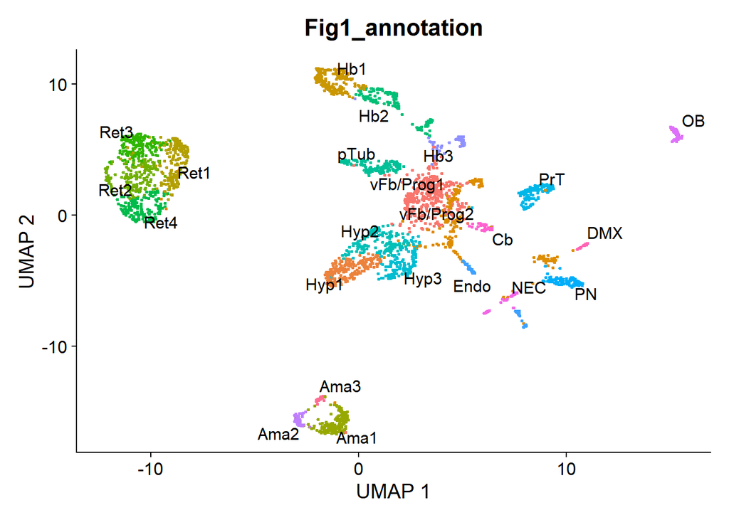

```r
# Generate UMAP visualization of annotated clusters for Figure 1C
UMAP_Fig1_annotation <- DimPlot(normalized_cells, pt.size = 0.5, group.by = "Fig1_annotation", label = T, repel = T) +
  NoLegend() +
  labs(x = "UMAP 1", y = "UMAP 2") +
    theme(
        plot.title = element_text(size = 16, face = "bold"))

UMAP_Fig1_annotation
```

```r
ggsave("Scritp3_Fig1_OwnData_DimPlot_.svg", plot = UMAP_Fig1_annotation, path = "Figures/Figure1_GeneralDataset", width = 5, height = 4)
```

## 9.2 Feature plots for neurotransmitter markers

```
## [1] "th"
```

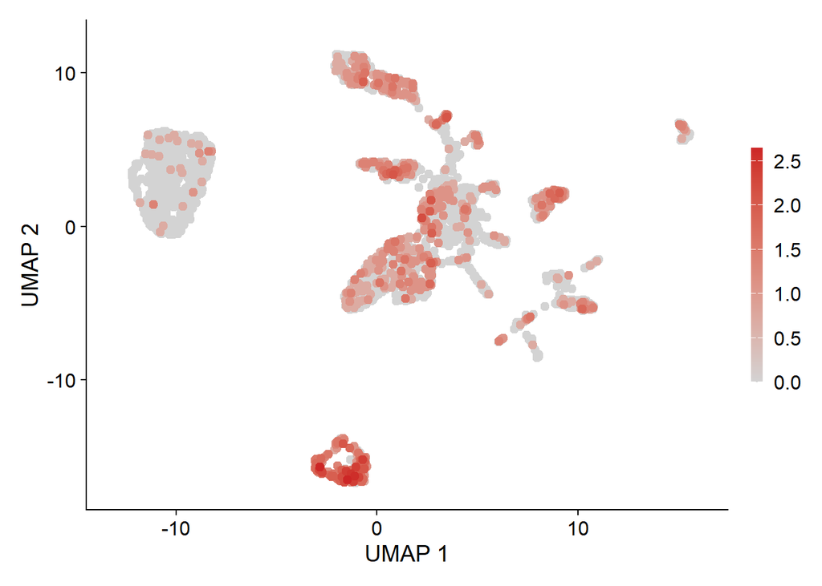

```
## [1] "slc6a2"
```

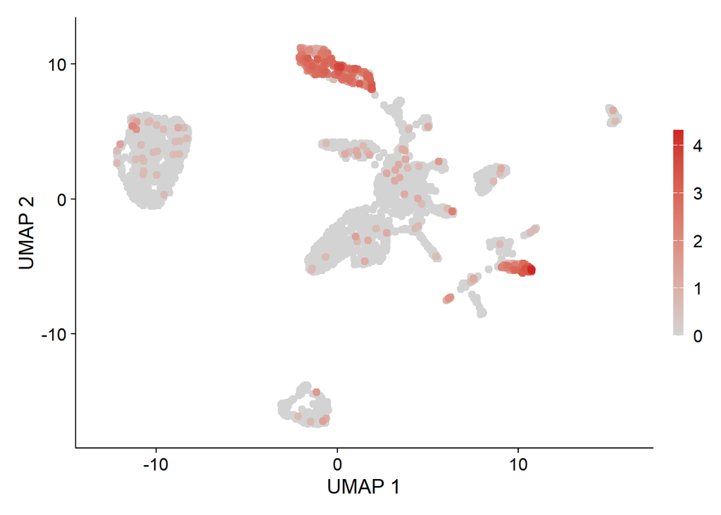

```
## [1] "slc18a2"
```

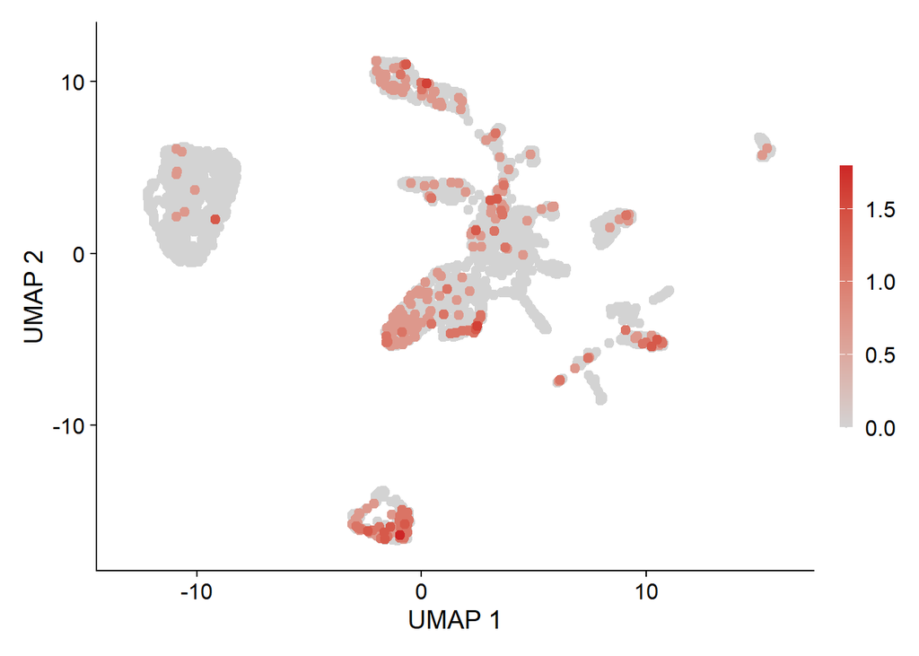

```
## [1] "ddc"
```

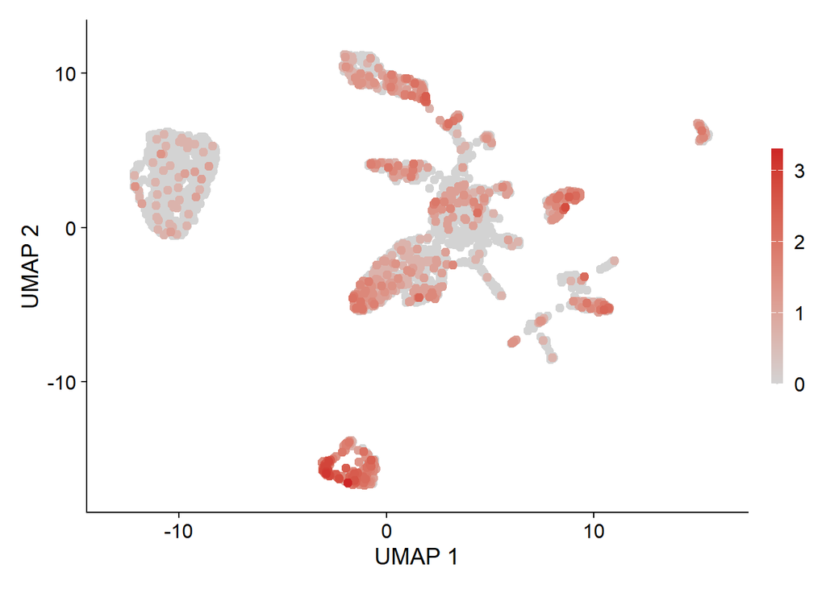

```
## [1] "dbh"
```

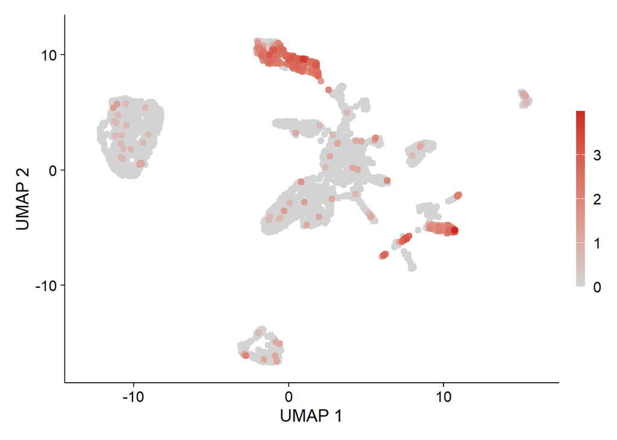

```
## [1] "slc6a3"
```

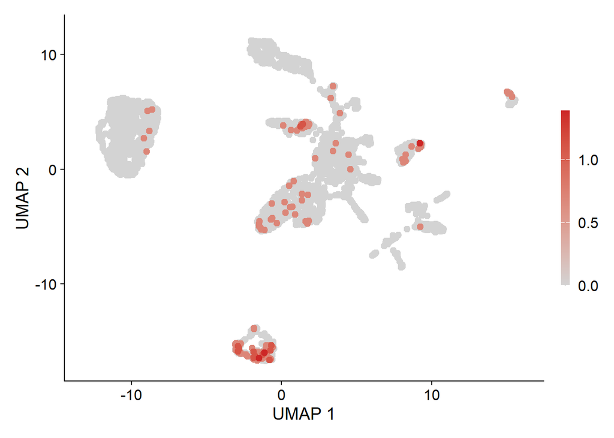

```
## [1] "th2"
```

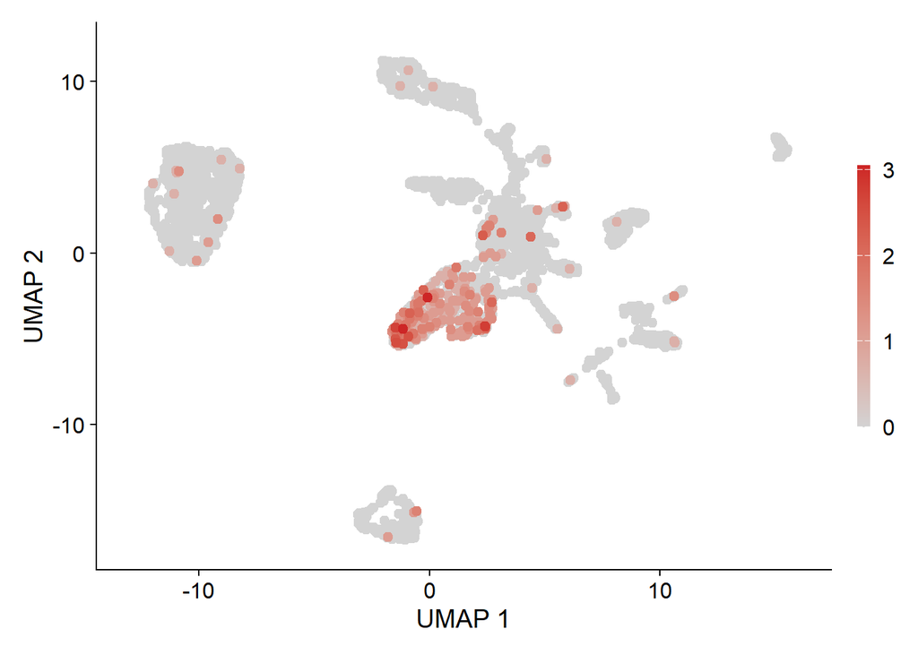

```
## [1] "slc17a6a"
```

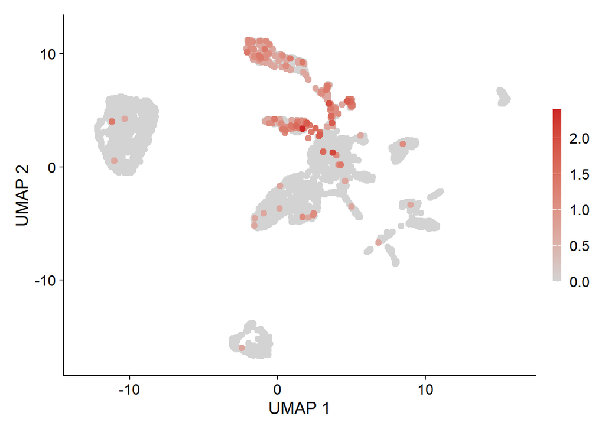

```
## [1] "slc17a6b"
```

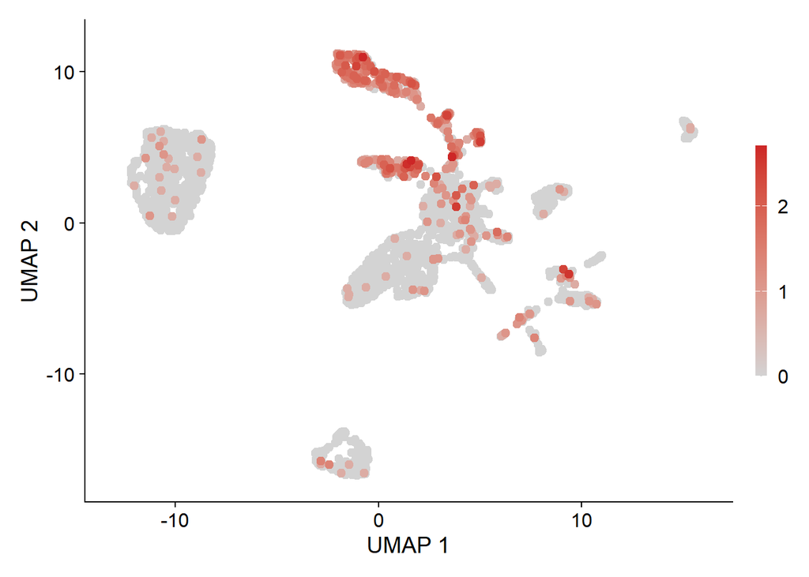

```
## [1] "slc17a7a"
```

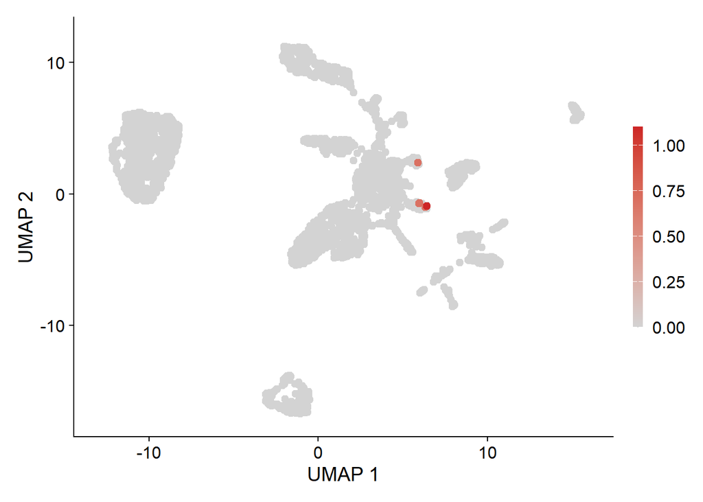

```
## [1] "gad1a"
```

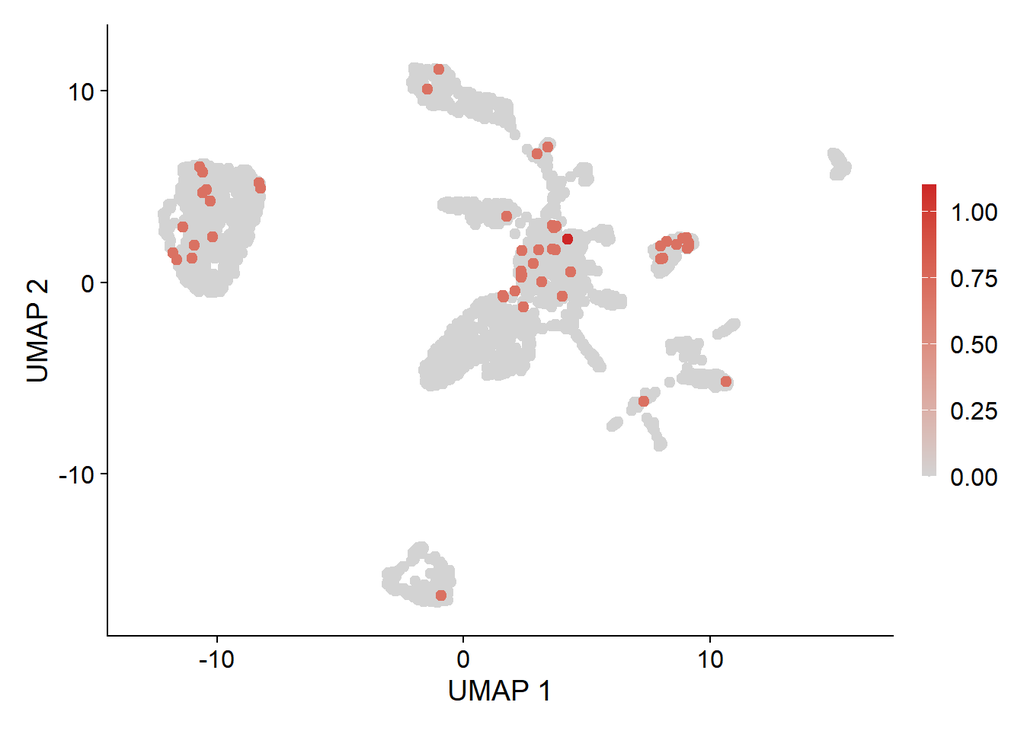

```
## [1] "gad1b"
```

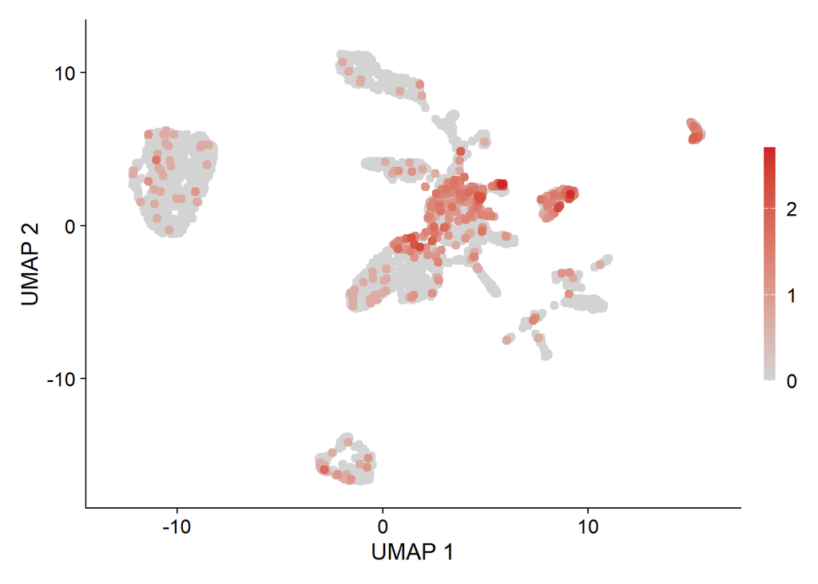

```
## [1] "gad2"
```

[3 more figures not shown]

```r
# Generate UMAP  plots showing expression (SCTransform normalized data slot) of neurotransmitter markers and additional genes used in Figure 1D and Figure S2A-D
genes <- c("th", "slc6a2", "slc18a2", "ddc", "dbh", "slc6a3", "th2", "slc17a6a", "slc17a6b", "slc17a7a", "gad1a", "gad1b", "gad2", "tulp1a", "krt18")

for (gene in genes) {
  plot <- FeaturePlot(normalized_cells, gene, pt.size = 2, order = T) +
    scale_colour_gradient(low="lightgrey", high="#cd2626") +
    labs(x = "UMAP 1", y = "UMAP 2", title = NULL) +
    guides(color = guide_colorbar(barwidth = 0.5, barheight = 10))
    plot_name <- paste("Script3_Fig1_OwnData_CA-markers_Plots_", gene, "_reds.svg")
    print(gene)
    print(plot)
    ggsave(plot_name, plot = plot, path = "Figures/Figure1_GeneralDataset/",
           width = 5, height = 4)
}
```

# 10. For figure 6

- We assessed the potential of the CA clusters to produce or receive specific neurotransmitter and neuropeptide types based on their expression of marker genes assosiated with the synthesis/release of neurotransmitter, genes encoding neuropeptides or genes encoding receptors for the resprective signaling types.
- Marker lists used can be also found in Table S6b and Table S6I. The neurotransmitter marker genes derive from a previously published list compiled by Martin and colleagues and were extended by NA synthesis and release markers as well as NA receptor encoding genes (Martin et al., 2022; DOI: 10.3389/fnmol.2022.818007). The assessed neuropeptides were selected based on entries in the HGNC database (https://www.genenames.org/data/genegroup/#!/group/1902, February 2025) and the homologs of the respective neuropeptide encoding genes were manually compiled for zebrafish
- The plot generated in this code is part of Figure 6A and B. The exported xlsx files are the basis of Table S6C-E and Table S6J-L.

## 10.1 Neurotransmitter Analysis

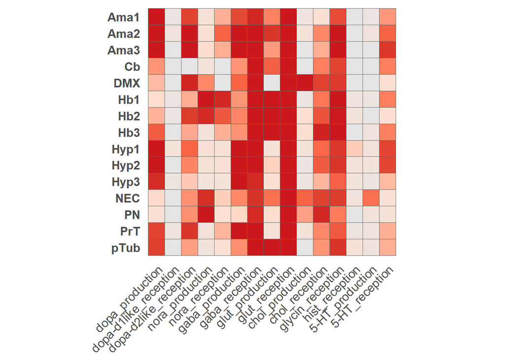

```r
seurat_object_to_analyse <- normalized_cells

# Use raw RNA counts for binary expression assignment of marker genes
DefaultAssay(seurat_object_to_analyse) <- "RNA"

# Minimum number of expressed marker genes required for assignment to a specific signaling type
expression_threshold <- 0

# Extract annotated cell clusters
cell_clusters <- as.data.frame(seurat_object_to_analyse$Fig1_annotation)


# Load t he neurotransmitter/neuropeptide marker gene lists that contain the genes associated with transmitter production and reception
gene_lists <- read.csv(file = "Resources/neurotransmitter_marker.csv", sep=";", skipNul = T, check.names = F)

# Get the raw count expression matrix from RNA assay
expr_matrix <- GetAssayData(seurat_object_to_analyse, assay = "RNA", slot = "count")

# Select marker genes present in the dataset and extract their expression values
all_marker_genes <- unname(unlist(gene_lists))
all_marker_genes <- all_marker_genes[all_marker_genes != ""]
valid_genes <- intersect(all_marker_genes, rownames(expr_matrix))
expr_matrix_relevant_genes <- expr_matrix[valid_genes, ]
expr_matrix_relevant_genes_cells <- t(as.data.frame(expr_matrix_relevant_genes))

# Calculate the average normalized expression for the marker genes per cluster for data export later
expr_matrix_relevant_genes_clusters <- AverageExpression(
  seurat_object_to_analyse,
  assays   = "RNA",
  slot     = "data",
  features = valid_genes,
  group.by = "Fig1_annotation",
  verbose  = FALSE
)

expr_matrix_relevant_genes_clusters <- as.data.frame(expr_matrix_relevant_genes_clusters)

expr_matrix_relevant_genes_clusters <- expr_matrix_relevant_genes_clusters[match(valid_genes, rownames(expr_matrix_relevant_genes_clusters)), , drop = FALSE]

expr_matrix_relevant_genes_clusters <- t(expr_matrix_relevant_genes_clusters)

################################################################################
# Assigning neurotransmitter/neuropeptide production and reception states
# For each signaling type cells are classified as as producing  or receiving based on expression of at least one marker gene.
################################################################################

# Define neurotransmitters/neuropeptide groups
all_neurotransmitters <- unique(sub("_out$|_in$", "", colnames(gene_lists)))

# Initialize empty matrices for assigning binary values for production and reception
production_matrix <- matrix(0, nrow = ncol(expr_matrix), ncol = length(all_neurotransmitters))
reception_matrix <- matrix(0, nrow = ncol(expr_matrix), ncol = length(all_neurotransmitters))

# Set cell names as row names for both matrices
rownames(production_matrix) <- colnames(expr_matrix)
rownames(reception_matrix) <- colnames(expr_matrix)

# Set neurotransmitters as column names
colnames(production_matrix) <- all_neurotransmitters
colnames(reception_matrix) <- all_neurotransmitters

# Track processed neurotransmitters
processed_neurotransmitters <- c()

# Loop through neurotransmitter/neuropeptide groups and identify producing/receiving cells
for (gene_group_name in all_neurotransmitters) {

  # Identify production marker genes
  production_column <- paste0(gene_group_name, "_out")
  if (production_column %in% colnames(gene_lists)) {
    production_markers <- gene_lists[[production_column]][gene_lists[[production_column]] %in% rownames(expr_matrix)]
  } else {
    production_markers <- NULL
  }

  # Identify reception marker genes
  reception_column <- paste0(gene_group_name, "_in")
  if (reception_column %in% colnames(gene_lists)) {
    reception_markers <- gene_lists[[reception_column]][gene_lists[[reception_column]] %in% rownames(expr_matrix)]
  } else {
    reception_markers <- NULL
  }

  # Assign cells expressing production or reception markers
  if (!is.null(production_markers) && length(production_markers) > expression_threshold) {
    production_cells <- colSums(expr_matrix[production_markers, , drop = FALSE] > 0) > 0
  } else {
    production_cells <- rep(FALSE, ncol(expr_matrix))  # Ensure 0 for all cells
  }

  if (!is.null(reception_markers) && length(reception_markers) > 0) {
    reception_cells <- colSums(expr_matrix[reception_markers, , drop = FALSE] > expression_threshold) > 0
  } else {
    reception_cells <- rep(FALSE, ncol(expr_matrix))  # Ensure 0 for all cells
  }
  # Identify dbh_cells
  dbh_cells <- expr_matrix["dbh", ] > expression_threshold

  # Separate DA and NA cells based on dbh expression to avoid assigning NA cells as DA due to shared markers
  if (gene_group_name == "dopa") {
    production_cells <- production_cells & !dbh_cells
    } else if (gene_group_name == "nora") {
      dbh_cells <- expr_matrix["dbh", ] > expression_threshold
      production_cells <- dbh_cells & production_cells
      }

  # Store assignments in matrices and Seurat metadata
  production_matrix[, gene_group_name] <- as.numeric(production_cells)
  reception_matrix[, gene_group_name] <- as.numeric(reception_cells)

  seurat_object_to_analyse[[paste0(gene_group_name, "_production")]] <- as.numeric(production_cells)
  seurat_object_to_analyse[[paste0(gene_group_name, "_reception")]] <- as.numeric(reception_cells)

  # Mark this neurotransmitter as processed
  processed_neurotransmitters <- c(processed_neurotransmitters, gene_group_name)
}

# Ensure all neurotransmitters are included in metadata, even if missing markers
for (gene_group_name in all_neurotransmitters) {
  if (!(gene_group_name %in% processed_neurotransmitters)) {
    seurat_object_to_analyse[[paste0(gene_group_name, "_production")]] <- 0
    seurat_object_to_analyse[[paste0(gene_group_name, "_reception")]] <- 0
    production_matrix[, gene_group_name] <- 0
    reception_matrix[, gene_group_name] <- 0
  }
}

###################################################################################
# Calculate fraction of cells per cluster expressing neurotransmitter markers
###################################################################################

# Threshold for visualization: only show transmitter/receptor groups that are expressed in at least 10% of cells in one cluster
threshold <- 0.1

# Get cluster identities from your Seurat object to include in the plot
clusters <- c("Hyp1","Hb1", "Ama1", "Hb2", "pTub", "Hyp2", "Hyp3", "PrT", "PN", "Hb3", "Ama2", "NEC","Cb", "DMX","Ama3")
clusters <- str_sort(clusters, decreasing = T)

# Initialize matrix to store the fraction of cells assigned to each neurotransmitter production and reception category per cluster
genegroup_Fraction_matrix <- matrix(0, nrow = length(clusters), ncol = length(colnames(gene_lists)))
rownames(genegroup_Fraction_matrix) <- clusters

# Rename columns to include both 'production' and 'reception' labels for each neurotransmitter
col_names <- colnames(gene_lists)
col_names <- str_replace(col_names, "_out", "_production")
col_names <- str_replace(col_names, "_in", "_reception")
colnames(genegroup_Fraction_matrix) <- col_names

# Loop to calculate the fraction of producing and receiving cells for each neurotransmitter within every annotated cluster
for (cluster in clusters) {
  # Select cells belonging to the current calculated cluster
  cluster_cells <- WhichCells(seurat_object_to_analyse, idents = cluster)

  for (name in colnames(gene_lists)) {
    # Strip the "_out" for production and "_in" for reception when accessing metadata
    name <- sub("_out$|_in$", "", name)

    # Define metadata column names for production and reception
    production_colname <- paste0(name, "_production")
    reception_colname <- paste0(name, "_reception")

    # Try to extract production data, otherwise return a vector of zeros
    production_cells <- try(seurat_object_to_analyse@meta.data[cluster_cells, production_colname], silent = TRUE)
    if (inherits(production_cells, "try-error")) {
      production_cells <- rep(0, length(cluster_cells))
    }

    # Try to extract reception data, otherwise return a vector of zeros
    reception_cells <- try(seurat_object_to_analyse@meta.data[cluster_cells, reception_colname], silent = TRUE)
    if (inherits(reception_cells, "try-error")) {
      reception_cells <- rep(0, length(cluster_cells))
    }

    # Calculate fraction of producing and receiving cells
    production_Fraction <- sum(production_cells) / length(cluster_cells)
    reception_Fraction <- sum(reception_cells) / length(cluster_cells)

    # Store calculated fractions
    try(genegroup_Fraction_matrix[cluster, paste(name, "production", sep = "_")] <- production_Fraction, silent = TRUE)
    try(genegroup_Fraction_matrix[cluster, paste(name, "reception", sep = "_")] <- reception_Fraction, silent = TRUE)
  }
}


###################################################################################
# Visualization and data export
###################################################################################

# Reshape the matrix for ggplot2
Fraction_df <- reshape2::melt(genegroup_Fraction_matrix)

# Change Fraction df colnames
colnames(Fraction_df) <- c("Cluster", "Neurotransmitter_Type", "Fraction")

# Identify neurotransmitter types where any cluster exceeds the threshold
valid_types <- Fraction_df %>%
  group_by(Neurotransmitter_Type) %>%
  dplyr::filter(any(Fraction >= threshold)) %>%
  pull(Neurotransmitter_Type) %>%
  unique()

# "Manual" override to include the signaling types in the plots that came up in either the analysis of the clusters of Figure 1c or 1e
# Neurotransmitter
valid_types <- list(
  "5-HT_production",
  "5-HT_reception",
  "chol_production",
  "chol_reception",
  "dopa_production",
  "dopa-d1like_reception",
  "dopa-d2like_reception",
  "gaba_production",
  "gaba_reception",
  "glut_production",
  "glut_reception",
  "glycin_reception",
  "hist_reception",
  "nora_production",
  "nora_reception"
  )

# All transmitter/peptide Fractions per cluster
Fraction_df_all <- Fraction_df

# Filter data: for visualization Keep all clusters for these neurotransmitters
Fraction_df <- Fraction_df %>%
  dplyr::filter(Neurotransmitter_Type %in% valid_types)



plot <- ggplot(Fraction_df, aes(x = Neurotransmitter_Type, y = Cluster, fill = Fraction)) +
  geom_tile(color = "black") +
          scale_fill_gradientn(
             colours = c("grey90","#fee0d2","#fb6a4a","#cb181d"),
            trans = "sqrt",
            limits = c(0, 0.75),#
            oob = scales::squish) +
          labs(title = NULL, x = NULL, y = NULL, fill = "Fraction of cells") +
          theme_minimal(base_size = 14) +
          theme(axis.text.x = element_text(angle = 45, hjust = 1, vjust = 1, size = 12),
                axis.text.y = element_text(size = 12, face = "bold",),
                plot.title = element_text(hjust = 0.5, face = "bold", size = 16),
                legend.position = "right",
                panel.grid.major = element_blank(),
                panel.grid.minor = element_blank()) +
                coord_fixed() +
                geom_tile(color = "grey40", linewidth = 0.25)+
                NoLegend()

ggsave("Script3_Fig6_Zebrafish_Own_Neurotransmitter_Sqrt.svg", plot = plot, path = "Figures/Figure6_TransmitterPeptideCodes/", width = 16, height = 8, bg = "white")

# Generate and save legend
legend_plot <- cowplot::ggdraw(get_legend(ggplot(Fraction_df, aes(x = Neurotransmitter_Type, y = Cluster, fill = Fraction)) +
    geom_tile() +
    scale_fill_gradientn(
    colours = c("grey90", "#fee0d2", "#fb6a4a", "#cb181d")) +
    theme_minimal() +
    theme(legend.position = "right")))

ggsave("Figures/Figure6_TransmitterPeptideCodes/Script3_Fig6_Zebrafish_Own_Neurotransmitter_Sqrt_Legend.svg", plot = legend_plot, bg = "white")
print(plot)
```

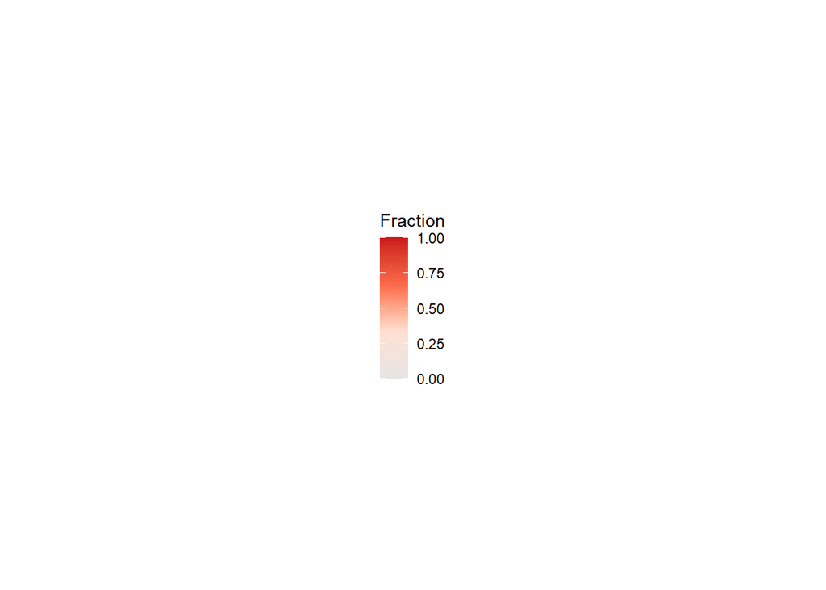

```r
print(legend_plot)
```

```r
# Save numerical data of the analysis
dataset_names <- list("used_markers_genes" = gene_lists, "raw_counts_cells" = expr_matrix_relevant_genes_cells, "assigned_clusters" = cell_clusters, "avg_norm_counts_cluster" = expr_matrix_relevant_genes_clusters, "fraction_per_cluster" = Fraction_df_all )
openxlsx::write.xlsx(dataset_names, file = "Figures/Figure6_TransmitterPeptideCodes/Script3_Fig6_Zebrafish_Own_Neurotransmitter_Analyis.xlsx", rowNames = TRUE)
```

## 10.2 Neuropeptide Analysis

```r
seurat_object_to_analyse <- normalized_cells

# Use raw RNA counts for binary expression assignment of marker genes
DefaultAssay(seurat_object_to_analyse) <- "RNA"

# Minimum number of expressed marker genes required for assignment to a specific signaling type
expression_threshold <- 0

# Extract annotated cell clusters
cell_clusters <- as.data.frame(seurat_object_to_analyse$Fig1_annotation)


# Load t he neurotransmitter/neuropeptide marker gene lists that contain the genes associated with transmitter production and reception
gene_lists <- read.csv(file = "Resources/neuropeptides_marker.csv", sep=";", skipNul = T, check.names = F)

# Get the raw count expression matrix from RNA assay
expr_matrix <- GetAssayData(seurat_object_to_analyse, assay = "RNA", slot = "count")

# Select marker genes present in the dataset and extract their expression values
all_marker_genes <- unname(unlist(gene_lists))
all_marker_genes <- all_marker_genes[all_marker_genes != ""]
valid_genes <- intersect(all_marker_genes, rownames(expr_matrix))
expr_matrix_relevant_genes <- expr_matrix[valid_genes, ]
expr_matrix_relevant_genes_cells <- t(as.data.frame(expr_matrix_relevant_genes))

# Calculate the average normalized expression for the marker genes per cluster for data export later
expr_matrix_relevant_genes_clusters <- AverageExpression(
  seurat_object_to_analyse,
  assays   = "RNA",
  slot     = "data",
  features = valid_genes,
  group.by = "Fig1_annotation",
  verbose  = FALSE
)

expr_matrix_relevant_genes_clusters <- as.data.frame(expr_matrix_relevant_genes_clusters)

expr_matrix_relevant_genes_clusters <- expr_matrix_relevant_genes_clusters[match(valid_genes, rownames(expr_matrix_relevant_genes_clusters)), , drop = FALSE]

expr_matrix_relevant_genes_clusters <- t(expr_matrix_relevant_genes_clusters)

################################################################################
# Assigning neurotransmitter/neuropeptide production and reception states
# For each signaling type cells are classified as as producing  or receiving based on expression of at least one marker gene.
################################################################################

# Define neurotransmitters/neuropeptide groups
all_neurotransmitters <- unique(sub("_out$|_in$", "", colnames(gene_lists)))

# Initialize empty matrices for assigning binary values for production and reception
production_matrix <- matrix(0, nrow = ncol(expr_matrix), ncol = length(all_neurotransmitters))
reception_matrix <- matrix(0, nrow = ncol(expr_matrix), ncol = length(all_neurotransmitters))

# Set cell names as row names for both matrices
rownames(production_matrix) <- colnames(expr_matrix)
rownames(reception_matrix) <- colnames(expr_matrix)

# Set neurotransmitters as column names
colnames(production_matrix) <- all_neurotransmitters
colnames(reception_matrix) <- all_neurotransmitters

# Track processed neurotransmitters
processed_neurotransmitters <- c()

# Loop through neurotransmitter/neuropeptide groups and identify producing/receiving cells
for (gene_group_name in all_neurotransmitters) {

  # Identify production marker genes
  production_column <- paste0(gene_group_name, "_out")
  if (production_column %in% colnames(gene_lists)) {
    production_markers <- gene_lists[[production_column]][gene_lists[[production_column]] %in% rownames(expr_matrix)]
  } else {
    production_markers <- NULL
  }

  # Identify reception marker genes
  reception_column <- paste0(gene_group_name, "_in")
  if (reception_column %in% colnames(gene_lists)) {
    reception_markers <- gene_lists[[reception_column]][gene_lists[[reception_column]] %in% rownames(expr_matrix)]
  } else {
    reception_markers <- NULL
  }

  # Assign cells expressing production or reception markers
  if (!is.null(production_markers) && length(production_markers) > expression_threshold) {
    production_cells <- colSums(expr_matrix[production_markers, , drop = FALSE] > 0) > 0
  } else {
    production_cells <- rep(FALSE, ncol(expr_matrix))  # Ensure 0 for all cells
  }

  if (!is.null(reception_markers) && length(reception_markers) > 0) {
    reception_cells <- colSums(expr_matrix[reception_markers, , drop = FALSE] > expression_threshold) > 0
  } else {
    reception_cells <- rep(FALSE, ncol(expr_matrix))  # Ensure 0 for all cells
  }
  # Identify dbh_cells
  dbh_cells <- expr_matrix["dbh", ] > expression_threshold

  # Separate DA and NA cells based on dbh expression to avoid assigning NA cells as DA due to shared markers
  if (gene_group_name == "dopa") {
    production_cells <- production_cells & !dbh_cells
    } else if (gene_group_name == "nora") {
      dbh_cells <- expr_matrix["dbh", ] > expression_threshold
      production_cells <- dbh_cells & production_cells
      }

  # Store assignments in matrices and Seurat metadata
  production_matrix[, gene_group_name] <- as.numeric(production_cells)
  reception_matrix[, gene_group_name] <- as.numeric(reception_cells)

  seurat_object_to_analyse[[paste0(gene_group_name, "_production")]] <- as.numeric(production_cells)
  seurat_object_to_analyse[[paste0(gene_group_name, "_reception")]] <- as.numeric(reception_cells)

  # Mark this neurotransmitter as processed
  processed_neurotransmitters <- c(processed_neurotransmitters, gene_group_name)
}

# Ensure all neurotransmitters are included in metadata, even if missing markers
for (gene_group_name in all_neurotransmitters) {
  if (!(gene_group_name %in% processed_neurotransmitters)) {
    seurat_object_to_analyse[[paste0(gene_group_name, "_production")]] <- 0
    seurat_object_to_analyse[[paste0(gene_group_name, "_reception")]] <- 0
    production_matrix[, gene_group_name] <- 0
    reception_matrix[, gene_group_name] <- 0
  }
}

###################################################################################
# Calculate fraction of cells per cluster expressing neurotransmitter markers
###################################################################################

# Threshold for visualization: only show transmitter/receptor groups that are expressed in at least 10% of cells in one cluster
threshold <- 0.1
```

```r
# Get cluster identities from your Seurat object to include in the plot
clusters <- c("Hyp1","Hb1", "Ama1", "Hb2", "pTub", "Hyp2", "Hyp3", "PrT", "PN", "Hb3", "Ama2", "NEC","Cb", "DMX","Ama3")
clusters <- str_sort(clusters, decreasing = T)

# Initialize matrix to store the fraction of cells assigned to each neurotransmitter production and reception category per cluster
genegroup_Fraction_matrix <- matrix(0, nrow = length(clusters), ncol = length(colnames(gene_lists)))
rownames(genegroup_Fraction_matrix) <- clusters

# Rename columns to include both 'production' and 'reception' labels for each neurotransmitter
col_names <- colnames(gene_lists)
col_names <- str_replace(col_names, "_out", "_production")
col_names <- str_replace(col_names, "_in", "_reception")
colnames(genegroup_Fraction_matrix) <- col_names

# Loop to calculate the fraction of producing and receiving cells for each neurotransmitter within every annotated cluster
for (cluster in clusters) {
  # Select cells belonging to the current calculated cluster
  cluster_cells <- WhichCells(seurat_object_to_analyse, idents = cluster)

  for (name in colnames(gene_lists)) {
    # Strip the "_out" for production and "_in" for reception when accessing metadata
    name <- sub("_out$|_in$", "", name)

    # Define metadata column names for production and reception
    production_colname <- paste0(name, "_production")
    reception_colname <- paste0(name, "_reception")

    # Try to extract production data, otherwise return a vector of zeros
    production_cells <- try(seurat_object_to_analyse@meta.data[cluster_cells, production_colname], silent = TRUE)
    if (inherits(production_cells, "try-error")) {
      production_cells <- rep(0, length(cluster_cells))
    }

    # Try to extract reception data, otherwise return a vector of zeros
    reception_cells <- try(seurat_object_to_analyse@meta.data[cluster_cells, reception_colname], silent = TRUE)
    if (inherits(reception_cells, "try-error")) {
      reception_cells <- rep(0, length(cluster_cells))
    }

    # Calculate fraction of producing and receiving cells
    production_Fraction <- sum(production_cells) / length(cluster_cells)
    reception_Fraction <- sum(reception_cells) / length(cluster_cells)

    # Store calculated fractions
    try(genegroup_Fraction_matrix[cluster, paste(name, "production", sep = "_")] <- production_Fraction, silent = TRUE)
    try(genegroup_Fraction_matrix[cluster, paste(name, "reception", sep = "_")] <- reception_Fraction, silent = TRUE)
  }
}


###################################################################################
# Visualization and data export
###################################################################################

# Reshape the matrix for ggplot2
Fraction_df <- reshape2::melt(genegroup_Fraction_matrix)

# Change Fraction df colnames
colnames(Fraction_df) <- c("Cluster", "Neurotransmitter_Type", "Fraction")



# Identify neurotransmitter types where any cluster exceeds the threshold
valid_types <- Fraction_df %>%
  group_by(Neurotransmitter_Type) %>%
  dplyr::filter(any(Fraction >= threshold)) %>%
  pull(Neurotransmitter_Type) %>%
  unique()

# "Manual" override to include the signaling types in the plots that came up in either the analysis of the clusters of Figure 1c or 1e # Neuropeptides
valid_types <- list(
  "Adcyap_production",
  "Adcyap_reception",
  "Adm_reception",
  "Agrp_reception",
  "Apln_production",
  "Calca_production",
  "Calca_reception",
  "Cb_reception",
  "Ccka_production",
  "Chga_production",
  "Crh_reception",
  "Galn_production",
  "Galn_reception",
  "Ghrh_production",
  "Grp_production",
  "Grp_reception",
  "Igf_production",
  "Igf_reception",
  "Ins_reception",
  "Kiss_reception",
  "Lep_reception",
  "Mln_reception",
  "Nmb_production",
  "Nmb_reception",
  "Nmu_production",
  "Npb_production",
  "Npp_production",
  "Npp_reception",
  "Npy_production",
  "Npy_reception",
  "Nts_production",
  "Nts_reception",
  "Pdyn_production",
  "Penk_production",
  "Penk_reception",
  "Pnoc_production",
  "Pomc_production",
  "Prl_production",
  "Pyy_production",
  "Sst_production",
  "Sst_production ",
  "Sst_reception",
  "Trh_reception",
  "Uts_production",
  "Vip_reception"
  )

# All transmitter/peptide Fractions per cluster
Fraction_df_all <- Fraction_df

# Filter data: for visualization Keep all clusters for these neurotransmitters
Fraction_df <- Fraction_df %>%
  dplyr::filter(Neurotransmitter_Type %in% valid_types)



plot <- ggplot(Fraction_df, aes(x = Neurotransmitter_Type, y = Cluster, fill = Fraction)) +
  geom_tile(color = "black") +
          scale_fill_gradientn(
             colours = c("grey90","#fee0d2","#fb6a4a","#cb181d"),
            trans = "sqrt",
            limits = c(0, 0.75),#
            oob = scales::squish) +
          labs(title = NULL, x = NULL, y = NULL, fill = "Fraction of cells") +
          theme_minimal(base_size = 14) +
          theme(axis.text.x = element_text(angle = 45, hjust = 1, vjust = 1, size = 12),
                axis.text.y = element_text(size = 12, face = "bold",),
                plot.title = element_text(hjust = 0.5, face = "bold", size = 16),
                legend.position = "right",
                panel.grid.major = element_blank(),
                panel.grid.minor = element_blank()) +
                coord_fixed() +
                geom_tile(color = "grey40", linewidth = 0.25)+
                NoLegend()

ggsave("Script3_Fig6_Zebrafish_Own_Neuropeptides_Sqrt.svg", plot = plot, path = "Figures/Figure6_TransmitterPeptideCodes/", width = 16, height = 8, bg = "white")

#______________________________________
# Generate and save legend
#______________________________________
legend_plot <- cowplot::ggdraw(get_legend(ggplot(Fraction_df, aes(x = Neurotransmitter_Type, y = Cluster, fill = Fraction)) +
    geom_tile() +
    scale_fill_gradientn(
    colours = c("grey90", "#fee0d2", "#fb6a4a", "#cb181d")) +
    theme_minimal() +
    theme(legend.position = "right")))
```

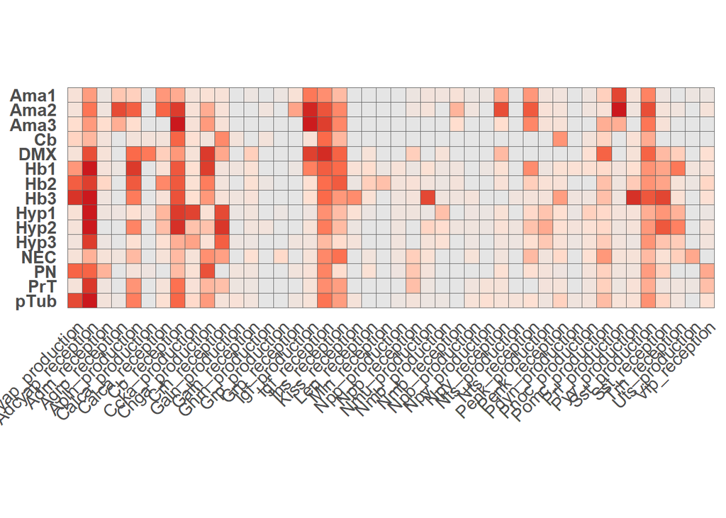

```r
#Save the legend
ggsave("Figures/Figure6_TransmitterPeptideCodes/Script3_Fig6_Zebrafish_Own_Neuropeptides_Sqrt_Legend.svg", plot = legend_plot, bg = "white")
print(plot)
```

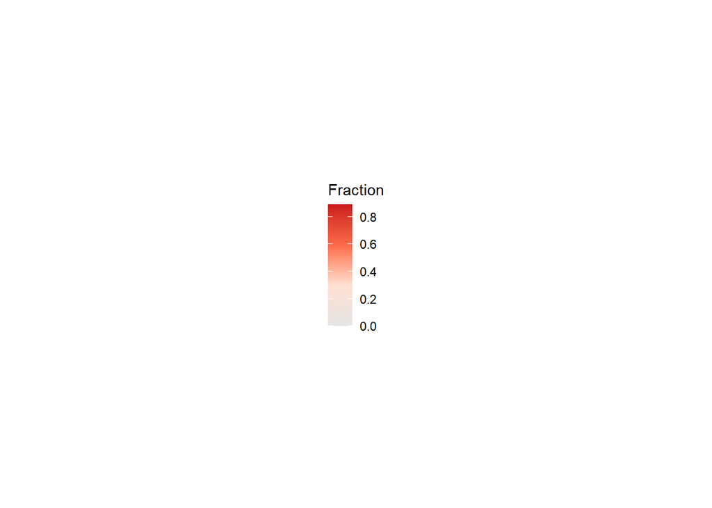

```r
print(legend_plot)
```

```r
# Save numerical data of the analysis
dataset_names <- list("used_markers_genes" = gene_lists, "raw_counts_cells" = expr_matrix_relevant_genes_cells, "assigned_clusters" = cell_clusters, "avg_norm_counts_cluster" = expr_matrix_relevant_genes_clusters, "fraction_per_cluster" = Fraction_df_all )



openxlsx::write.xlsx(dataset_names, file = "Figures/Figure6_TransmitterPeptideCodes/Script3_Fig6_Zebrafish_Own_Neuropeptides_Analyis.xlsx", rowNames = TRUE)
```

# 11. Save raw count matrix as .csv file for GEO submission

```r
normalized_cells <-readRDS("RDS_files/Script3_Armbruster2026_annotated.rds")
```

```r
# Extract count matrix
normalized_cells_count_matrix <- GetAssayData(normalized_cells, assay = "RNA", slot = "counts")


normalized_cells_count_matrix <- t(as.matrix(normalized_cells_count_matrix))

# Add cluster names to cell names
clusters <-unname(normalized_cells$Fig1_annotation)
cellnames <- rownames(normalized_cells_count_matrix)
cellnames_with_cluster <- paste(cellnames, clusters, sep = "_")
rownames(normalized_cells_count_matrix) <- cellnames_with_cluster
normalized_cells_count_matrix <- t(as.matrix(normalized_cells_count_matrix))

# Save as .csv
write.csv(normalized_cells_count_matrix, file = "rawcount_csv_of_Figure1c_clusters/Armbruster2026_raw_count_matrix.csv")
```

# 12. Average TF counts per cluster

- Get the average normalized expression from the RNA assay of all transcription factors expressed in the CA clusters.
- This is the basis of Table S1C.

```r
normalized_cells <- readRDS("RDS_files/Script3_Armbruster2026_annotated.rds")

norm_avgcounts_per_cluster <- AverageExpression(
  normalized_cells,
  assays   = "RNA",
  slot     = "data",
  group.by = "Fig1_annotation",
  verbose  = FALSE,
  features = TFlist$gene

)


df_norm_avgcounts_per_cluster <- data.frame(norm_avgcounts_per_cluster)

openxlsx::write.xlsx(df_norm_avgcounts_per_cluster, file = "other_data_tables/Script3_Figure1c_clusters_avgnormalizedTFcounts.xlsx", rowNames=T)
```

```r
# Remove objects to reduce memory usage
rm(list=ls())
gc()
```

```
##            used  (Mb) gc trigger (Mb)  max used   (Mb)
## Ncells 12185666 650.8   22205954 1186  22205954 1186.0
## Vcells 22460281 171.4  323084138 2465 403855172 3081.2
```